# Data624_HW6

## Exercise 8

For the United States GDP series (from global_economy): a. if necessary, find a suitable Box-Cox transformation for the data;

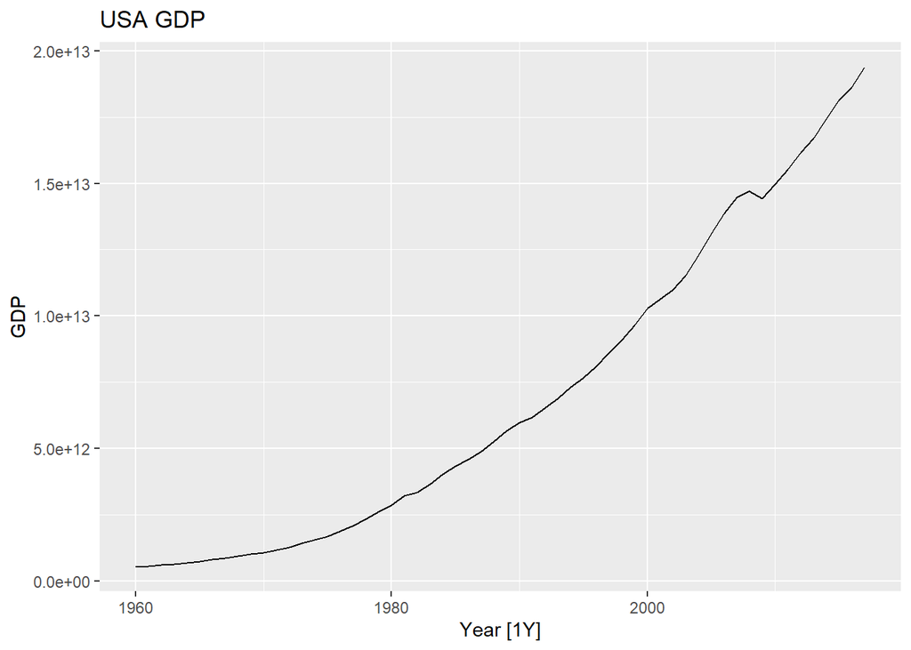

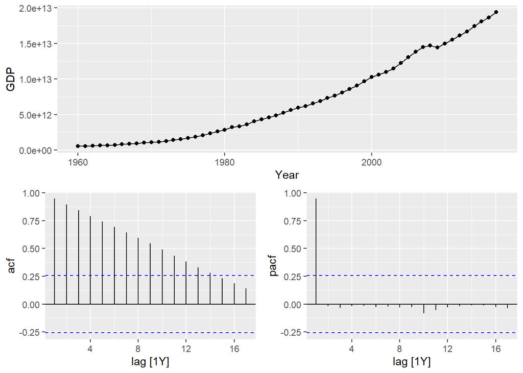

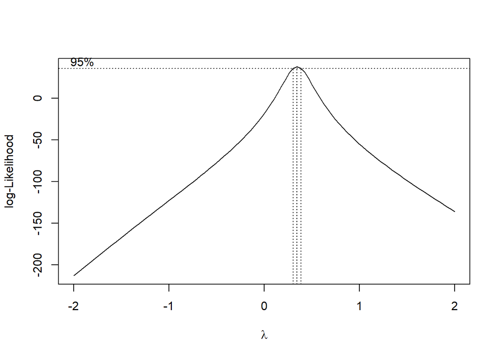

```
## [1] 0.3434343
```

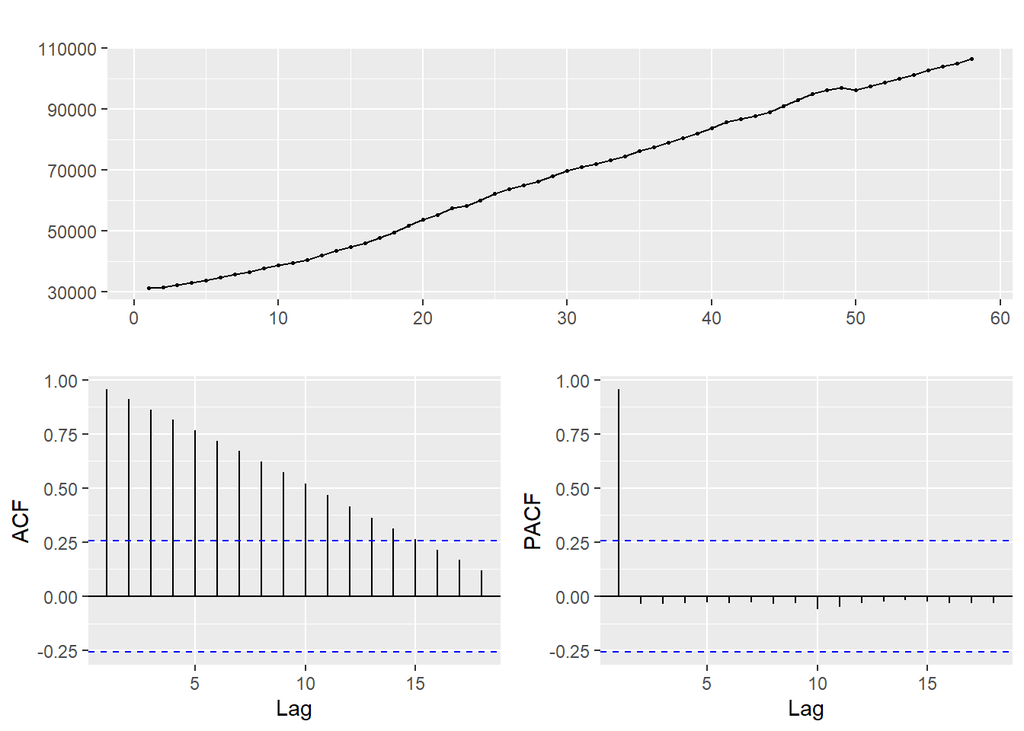

2. fit a suitable ARIMA model to the transformed data using ARIMA();
3. try some other plausible models by experimenting with the orders chosen;

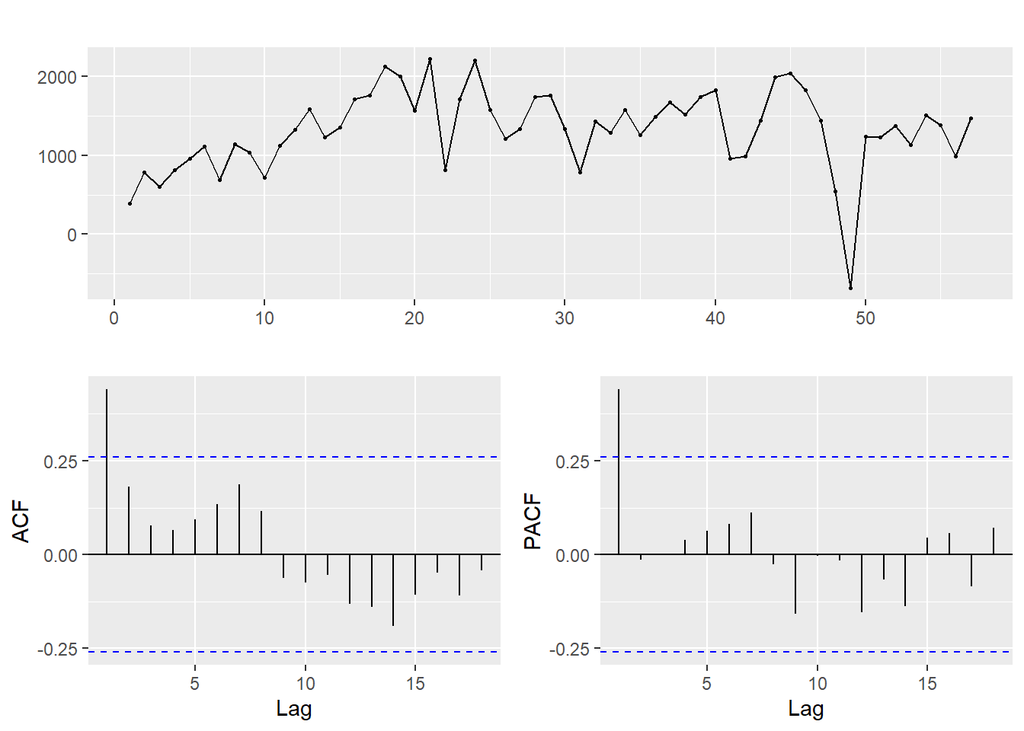

```
##
## #######################
## # KPSS Unit Root Test #
## #######################
##
## Test is of type: mu with 5 lags.
##
## Value of test-statistic is: 0.0141
##
## Critical value for a significance level of:
##                 10pct  5pct 2.5pct  1pct
## critical values 0.347 0.463  0.574 0.739
```

4. choose what you think is the best model and check the residual diagnostics;
5. produce forecasts of your fitted model. Do the forecasts look reasonable?
6. compare the results with what you would obtain using ETS() (with no transformation).

```
## # A tibble: 6 x 9
##   Country       .model    sigma2 log_lik   AIC  AICc   BIC ar_roots  ma_roots
##   <fct>         <chr>      <dbl>   <dbl> <dbl> <dbl> <dbl> <list>    <list>
## 1 United States arima222 2.28e22  -1521. 3052. 3053. 3062. <cpl [2]> <cpl [2]>
## 2 United States arima022 2.61e22  -1524. 3054. 3055. 3060. <cpl [0]> <cpl [2]>
## 3 United States stepwise 2.61e22  -1524. 3054. 3055. 3060. <cpl [0]> <cpl [2]>
## 4 United States search   2.61e22  -1524. 3054. 3055. 3060. <cpl [0]> <cpl [2]>
## 5 United States arima021 2.92e22  -1528. 3059. 3059. 3063. <cpl [0]> <cpl [1]>
## 6 United States arima212 3.10e22  -1530. 3061. 3061. 3063. <cpl [0]> <cpl [0]>
```

```
## [1] "we choose  ARIMA(2,2,2) model because of the lowest AICc"
```

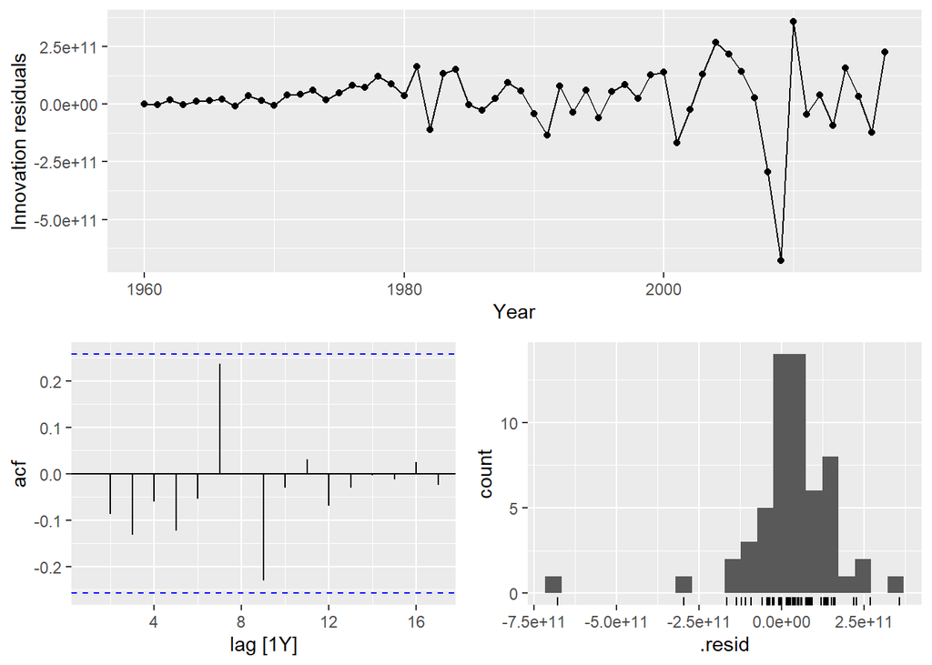

```
## [1] "Looks like a normal residual plot"
```

```
## [1] "Forescast of fitted ARIMA(0,2,2) model ...plot below"
```

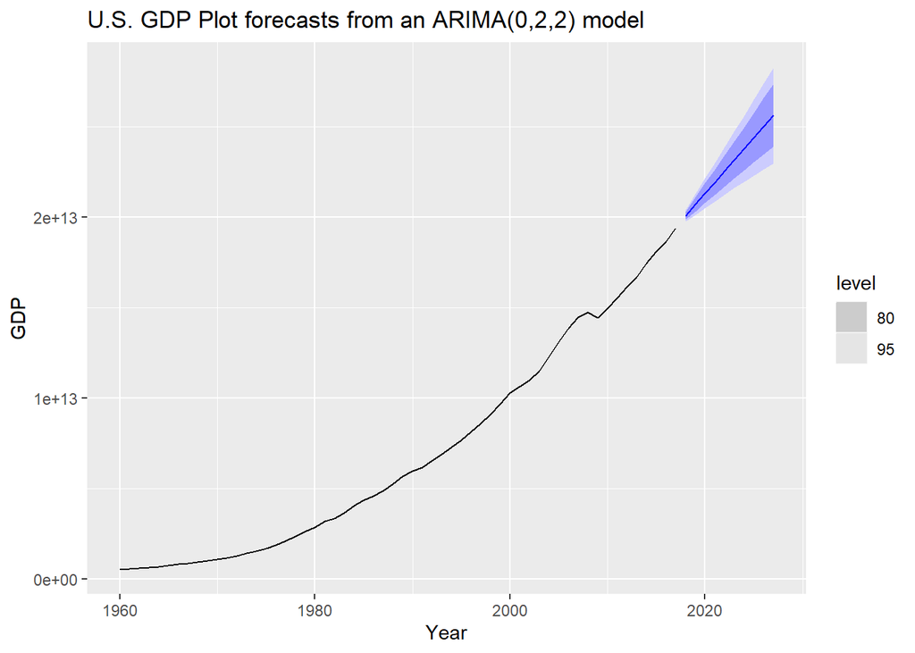

```
## [1] "Forescast of fitted ARIMA(2,2,2) model looks reasonable...plot below"
```

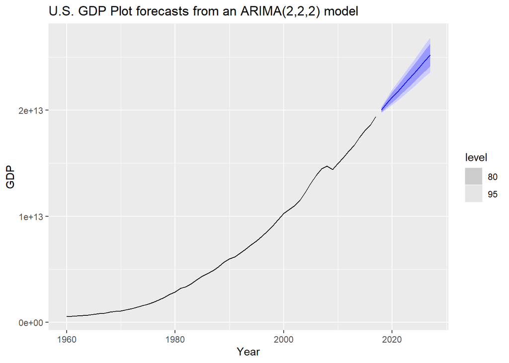

```
## [1] "Forescast of fitted ARIMA(0,2,1) model....plot below"
```

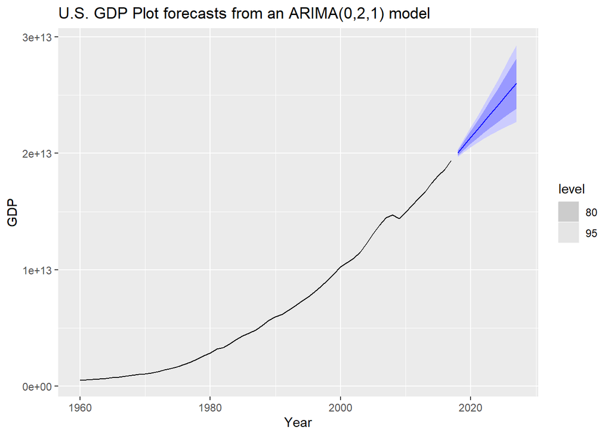

```
## # A tibble: 1 x 4
##   Country       .model   lb_stat lb_pvalue
##   <fct>         <chr>      <dbl>     <dbl>
## 1 United States arima222    10.7     0.155
```

```
## [1] "Let's see the results with ETS"
```

```
## ETS(M,A,N)
##
## Call:
##  ets(y = .)
##
##   Smoothing parameters:
##     alpha = 0.9991
##     beta  = 0.5012
##
##   Initial states:
##     l = 448093333333.703
##     b = 64917355686.8708
##
##   sigma:  0.026
##
##      AIC     AICc      BIC
## 3190.787 3191.941 3201.089
```

[output not shown]